# Guided Project: Statistical Transformations and Coordinate Systems

CIS-3901 · Module 12

Author

Samuel Taylor

Published

November 10, 2026

## My data

Fairness: Adult; Sports: MMA_Decisions. Each: Adult - One row is one person (5000 Rows); MMA_Decisions - One row is one match (5000 Rows).

```r
put_in_place("fairness.csv", "data/tidy")
put_in_place("sports.csv", "data/sports")

fairness <- read_csv("data/tidy/fairness.csv", show_col_types = FALSE)
sports <- read_csv("data/sports/sports.csv", show_col_types = FALSE)

if (looks_damaged(fairness) || looks_damaged(sports)) {
  stop("One of your data files looks damaged (each row in one column): it ",
       "may have been re-saved by a spreadsheet app. Ask your instructor ",
       "for a fresh copy.", call. = FALSE)
}

# Your columns
glimpse(fairness)
```

```
Rows: 5,000
Columns: 15
$ person_id      <dbl> 1, 2, 3, 4, 5, 6, 7, 8, 9, 10, 11, 12, 13, 14, 15, 16, …
$ age            <dbl> 54, 28, 42, 38, 33, 33, 46, 42, 47, 61, 46, 33, 18, 28,…
$ workclass      <chr> "Private", "Private", "Private", "State-gov", "Private"…
$ education      <chr> "HS-grad", "Assoc-acdm", "10th", "Some-college", "Some-…
$ education_num  <dbl> 9, 12, 6, 10, 10, 9, 10, 2, 14, 10, 9, 9, 9, 13, 9, 9, …
$ marital_status <chr> "Divorced", "Married-civ-spouse", "Divorced", "Separate…
$ occupation     <chr> "Craft-repair", "Exec-managerial", "Adm-clerical", "Exe…
$ relationship   <chr> "Not-in-family", "Wife", "Unmarried", "Not-in-family", …
$ race           <chr> "White", "White", "White", "White", "White", "Black", "…
$ sex            <chr> "Male", "Female", "Female", "Female", "Male", "Female",…
$ capital_gain   <dbl> 0, 0, 0, 0, 0, 0, 0, 0, 0, 0, 0, 0, 0, 0, 0, 0, 0, 0, 0…
$ capital_loss   <dbl> 1741, 0, 0, 0, 0, 0, 0, 0, 0, 0, 0, 0, 0, 0, 0, 0, 0, 0…
$ hours_per_week <dbl> 40, 16, 40, 45, 40, 40, 40, 55, 45, 40, 40, 40, 48, 47,…
$ native_country <chr> "United-States", "United-States", "United-States", "Uni…
$ income         <chr> "<=50K", ">50K", "<=50K", "<=50K", "<=50K", "<=50K", ">…
```

```r
glimpse(sports)
```

```
Rows: 5,000
Columns: 32
$ date          <date> 2001-05-04, 2001-06-29, 2001-09-28, 2001-09-28, 2001-09…
$ event         <chr> "UFC 31: Locked & Loaded", "UFC 32: Showdown in the Mead…
$ arena         <chr> "Trump Taj Mahal Casino Resort", "Continental Airlines A…
$ city          <chr> "Atlantic City, New Jersey, USA", "East Rutherford, New …
$ fighter1      <chr> "DeSouza", "Kondo", "Matyushenko", "Hallman", "Bustamant…
$ fighter2      <chr> "Berger", "Matyushenko", "Ortiz", "Pulver", "Liddell", "…
$ result_type   <chr> "Unanimous", "Unanimous", "Unanimous", "Unanimous", "Una…
$ judge1        <chr> "Andujar", "Andujar", "Crosby", "Crosby", "Crosby", "Mul…
$ judge1_score1 <dbl> 30, 27, 43, 47, 28, 28, 30, 49, 28, 45, 27, 26, 30, 27, …
$ judge1_score2 <dbl> 27, 30, 50, 49, 29, 29, 26, 43, 29, 48, 30, 30, 26, 30, …
$ judge2        <chr> "Crosby", "Crosby", "Hamilton", "Mullen", "Schorle", "Sc…
$ judge2_score1 <dbl> 29, 26, 44, 47, 27, 27, 30, 49, 27, 47, 27, 26, 30, 27, …
$ judge2_score2 <dbl> 28, 30, 50, 48, 29, 29, 27, 44, 29, 47, 30, 30, 27, 30, …
```

[output cut: 19 more lines]

```r
# PART A · FAIRNESS ==========================================================

# A0 · Your group and your outcome ------------------------------------------
# Session 1, slide 17: "My outcome is ___. My group is ___."
# YOUR TURN: replace "replace me" with your group column (no quotes), and
# FALSE with a TRUE/FALSE condition for your outcome. Examples (use YOUR
# columns; the Guided Project page lists them for every class dataset):
#   group = sex,           has_outcome = income == ">50K"
#   group = age,           has_outcome = readmit_30_days == 1
```

## Part A · Fairness

**My group:** Sex. **My outcome:** income == “>50K”.

### A0 · My group and my outcome

```r
a_data <- fairness %>%
  mutate(
    group = sex,
    has_outcome = (income == ">50K")
  )

a_data %>%
  count(group, has_outcome) %>%
  print(n = Inf)
```

```
# A tibble: 4 × 3
  group  has_outcome     n
  <chr>  <lgl>       <int>
1 Female FALSE        1477
2 Female TRUE          180
3 Male   FALSE        2328
4 Male   TRUE         1015
```

### A1 · The rate within each group (question A)

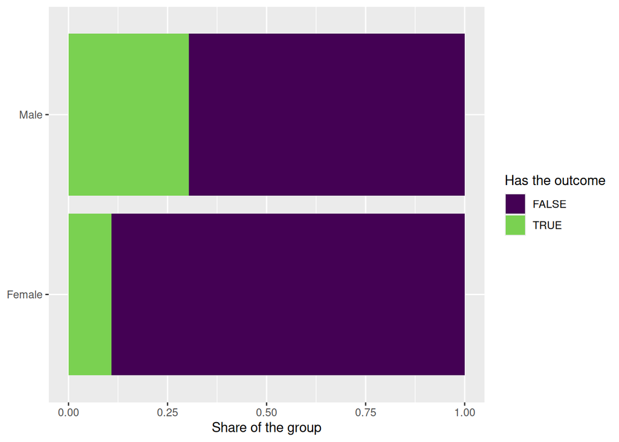

Figure 1: Share of each group with the outcome.

```r
a1 <- ggplot(a_data, aes(y = group, fill = has_outcome)) +
  geom_bar(position = "fill") +
  labs(x = "Share of the group", y = NULL, fill = "Has the outcome")

show_plot(a1)
```

WRITE (2–3 sentences): I predicted males would have a higher rate of meeting the criteria; the plot has also reflected this. Males have a higher rate and proportion of incomes over 50k, while females have the lower rate. When we divide by the group’s own total, it makes our conclusion far easier to defend when reading for ratios.

### A2 · Rates with their standard error

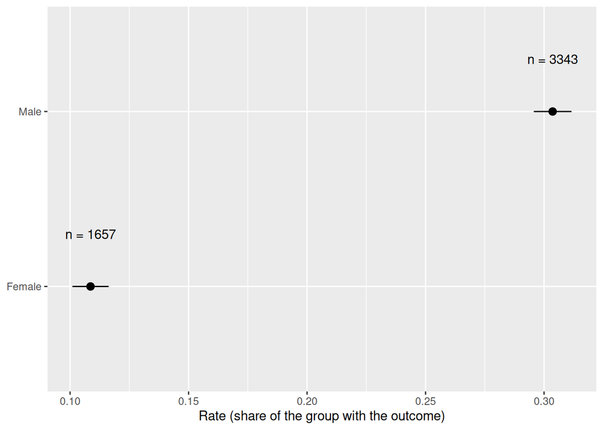

Figure 2: Rate in each group, with ± one standard error and the group size.

```r
a2_rates <- a_data %>%
  drop_na(has_outcome) %>%
  group_by(group) %>%
  summarize(
    n = n(),
    rate = mean(has_outcome),
    se = sqrt(rate * (1 - rate) / n)
  )

a2 <- ggplot(a2_rates,
             aes(x = rate, y = group,
                 xmin = rate - se,
                 xmax = rate + se)) +
  geom_pointrange() +
  # Many groups, and the labels touch the points? Keep every group, and use
  # vjust = -0.8, size = 3 instead of nudge_y = 0.3.
  geom_text(aes(label = paste("n =", n)), nudge_y = 0.3) +
  labs(x = "Rate (share of the group with the outcome)", y = NULL)

show_plot(a2)
```

WRITE (2–3 sentences): Neither range is comparably wider; however, if the smaller group was wider, it would show that the smaller sample varied by much. This plot keeps the small group visible, while showing the confidence level in the data point’s location.

### A3 · Zoom or filter?

```r
a3_table <- a_data %>%
  count(group) %>%
  arrange(desc(n))
a3_table
```

```
# A tibble: 2 × 2
  group      n
  <chr>  <int>
1 Male    3343
2 Female  1657
```

```r
a3_start <- 828

a3_counts <- ggplot(a_data, aes(y = group)) +
  geom_bar() +
  labs(x = "Count", y = NULL)

a3_zoom <- a3_counts +
  coord_cartesian(xlim = c(a3_start, max(a3_table$n)), expand = FALSE)

# A warning about removed rows here is expected (Session 2, slide 5).
a3_filter <- a3_counts +
  scale_x_continuous(limits = c(a3_start, max(a3_table$n)))

# Lie Factor (Tufte, 2001, p. 57) of the zoomed plot, largest vs smallest
# group: how many times the picture exaggerates the difference.
a3_largest <- max(a3_table$n)
a3_smallest <- min(a3_table$n)
a3_lie_factor <-
  ((a3_largest - a3_start) / (a3_smallest - a3_start)) /
  (a3_largest / a3_smallest)
a3_lie_factor
```

```
[1] 1.503729
```

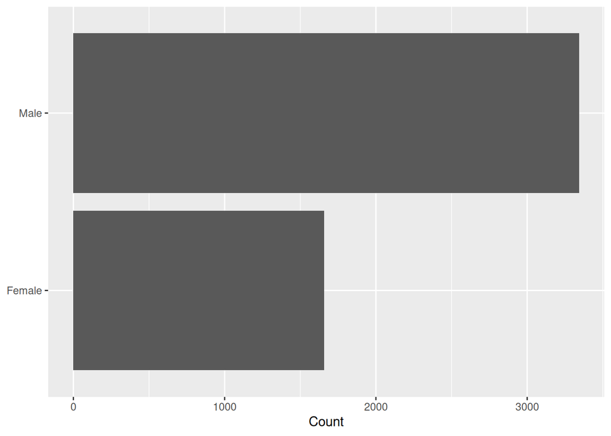

(a) From 0

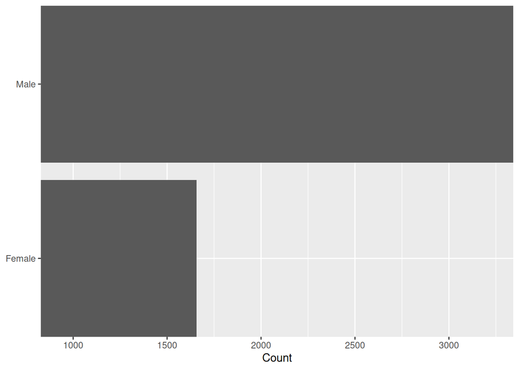

(b) Zoomed

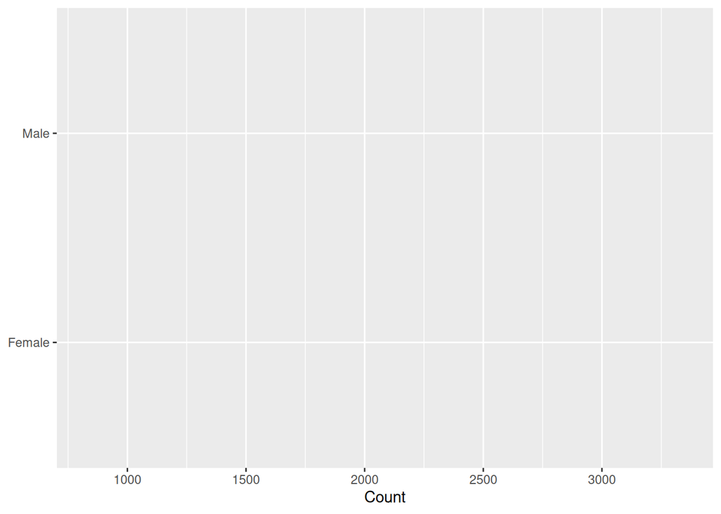

(c) Filtered

Figure 3: Counts per group: from 0, zoomed and filtered.

```r
show_plot(a3_counts)
show_plot(a3_zoom)
show_plot(a3_filter)
```

The zoomed plot’s Lie Factor (largest vs smallest group) is 1.5.

WRITE (3–4 sentences): The counts plot displays the total amount of males and females; the zoom plot shows the same, but cuts off to where the female count looks smaller– finally, the filter plot shows nothing, as the data falls outside of the scale range. The lie factor supports our idea of how the zoom plot is warped, stating that the size of the bars would roughly 1.504 the size. Considering publishing, I feel that the simple counts plot would reflect the most accurate data.

### A4 · Each group’s share of everyone with the outcome (question B)

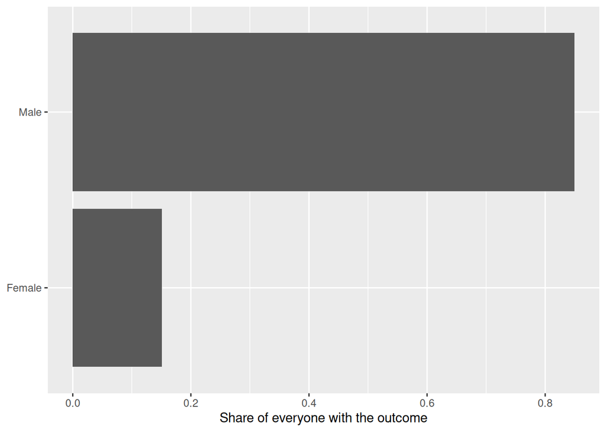

Figure 4: Each group’s share of everyone with the outcome.

```r
a4_shares <- a_data %>%
  filter(has_outcome) %>%
  count(group) %>%
  mutate(share = n / sum(n))

a4 <- ggplot(a4_shares, aes(x = share, y = group)) +
  geom_col() +
  labs(x = "Share of everyone with the outcome", y = NULL)

show_plot(a4)
```

WRITE (2–3 sentences): Questions A and B point to the same conclusion; this is due to the fact that fewer females within their group are in the outcome, and therefore make up the minority of the outcome group.

## Part B · Sports

**My group, outcome and value:** Rounds, Agreement, and Judge1_Margin

### B0 · My group, outcome and value

```r
b_data <- sports %>%
  mutate(
    group = factor(rounds),
    has_outcome = agreement == 'Agree',
    value = abs(judge1_margin)
  )

b_data %>%
  count(group, has_outcome) %>%
  print(n = Inf)
```

```
# A tibble: 6 × 3
  group has_outcome     n
  <fct> <lgl>       <int>
1 3     FALSE        1119
2 3     TRUE         3506
3 5     FALSE          80
4 5     TRUE          271
5 12    FALSE          11
6 12    TRUE           13
```

```r
summary(b_data$value)
```

```
   Min. 1st Qu.  Median    Mean 3rd Qu.    Max.
  0.000   1.000   1.000   2.088   3.000  10.000
```

### B1 · The rate within each group

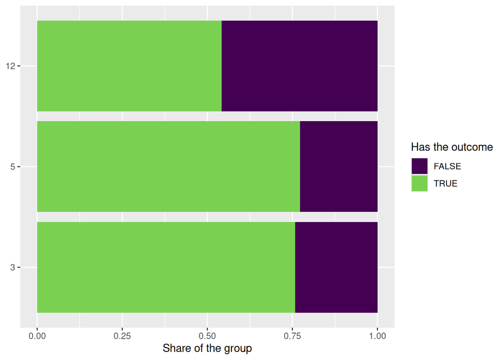

Figure 5: Share of each group with the outcome.

```r
b1 <- ggplot(b_data, aes(y = group, fill = has_outcome)) +
  geom_bar(position = "fill") +
  labs(x = "Share of the group", y = NULL, fill = "Has the outcome")

show_plot(b1)
```

WRITE (2 sentences): The plot displays the rate of agreement; shares is a more comparable way to consider the agreement ratio in each category of fight, as there are far fewer fights in the 5 and 12 round matches compared to the 3 round matches.

### B2 · A mean with its two spreads

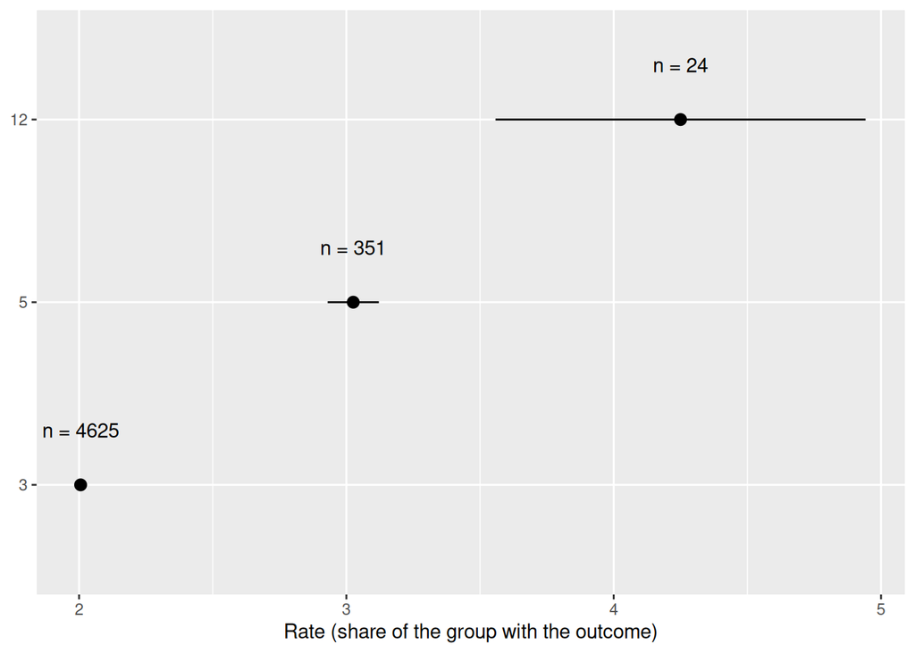

Figure 6: Mean in each group, with ± one standard error and group size.

```r
b2_summary <- b_data %>%
  drop_na(value) %>%
  group_by(group) %>%
  summarize(
    n = n(),
    mean = mean(value),
    sd = sd(value),
    se = sd / sqrt(n)
  )

b2 <- ggplot(b2_summary,
             aes(x = mean, y = group,
                 xmin = mean - se,
                 xmax = mean + se)) + geom_pointrange() +
                 geom_text(aes(label = paste("n =", n)), nudge_y = 0.3) +
                 labs(x = "Rate (share of the group with the outcome)", y = NULL)

show_plot(b2)
```

Table 1: Group size, mean, sd and se.

| group | n | mean | sd | se |
| --- | --- | --- | --- | --- |
| 3 | 4625 | 2.006 | 1.159 | 0.017 |
| 5 | 351 | 3.026 | 1.793 | 0.096 |
| 12 | 24 | 4.250 | 3.391 | 0.692 |

WRITE (2–3 sentences):The groups of 5 and 12 rounds have a fairly wide margin, but it is slimmed significantly when considering the standard deviation. This tells us that although there is a large gap between the averages of these score margins, there is a much smaller gap when considering the lower end of the possible score margin in the 12 round matches.

### B3 · Zoom or filter?

```r
b3_table <- b_data %>%
  count(group) %>%
  arrange(desc(n))
b3_table
```

```
# A tibble: 3 × 2
  group     n
  <fct> <int>
1 3      4625
2 5       351
3 12       24
```

```r
b3_start <- 12

b3_counts <- ggplot(b_data, aes(y = group)) +
  geom_bar() +
  labs(x = "Count", y = NULL)

b3_zoom <- b3_counts +
  coord_cartesian(xlim = c(b3_start, max(b3_table$n)), expand = FALSE)

b3_filter <- b3_counts +
  scale_x_continuous(limits = c(b3_start, max(b3_table$n)))

b3_lie_factor <-
  ((max(b3_table$n) - b3_start) / (min(b3_table$n) - b3_start)) /
  (max(b3_table$n) / min(b3_table$n))
b3_lie_factor
```

```
[1] 1.994811
```

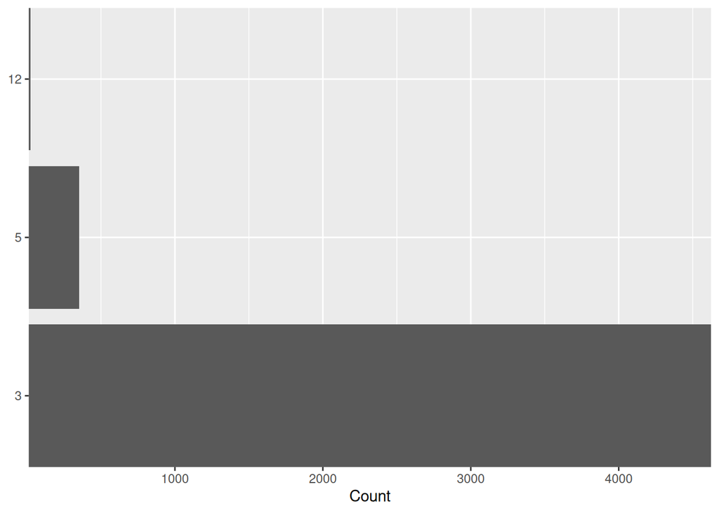

(a) Zoomed

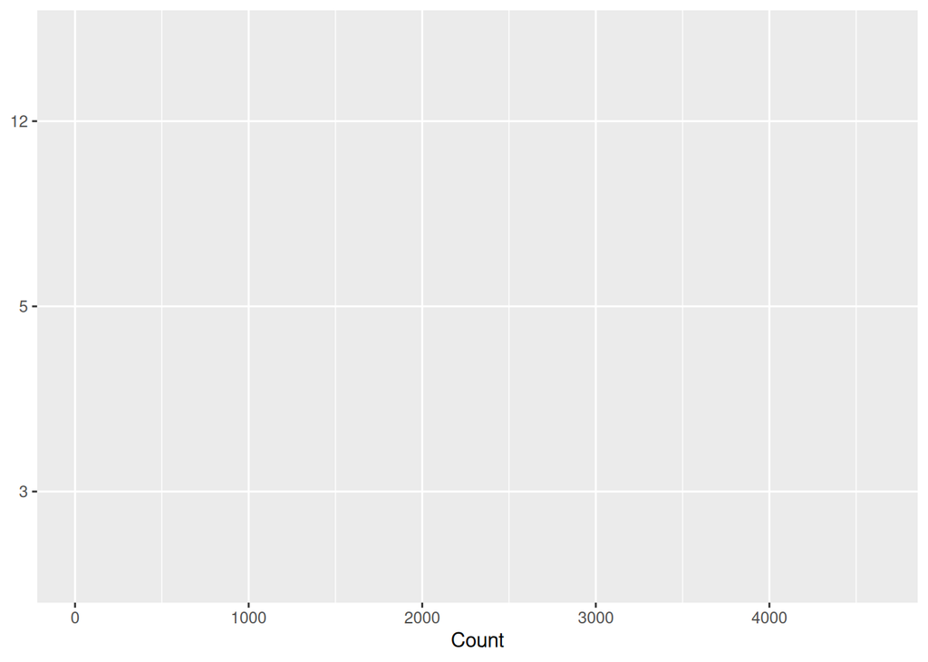

(b) Filtered

Figure 7: Counts per group: zoomed and filtered.

```r
show_plot(b3_zoom)
show_plot(b3_filter)
```

### B4 · Each group’s share of everyone with the outcome

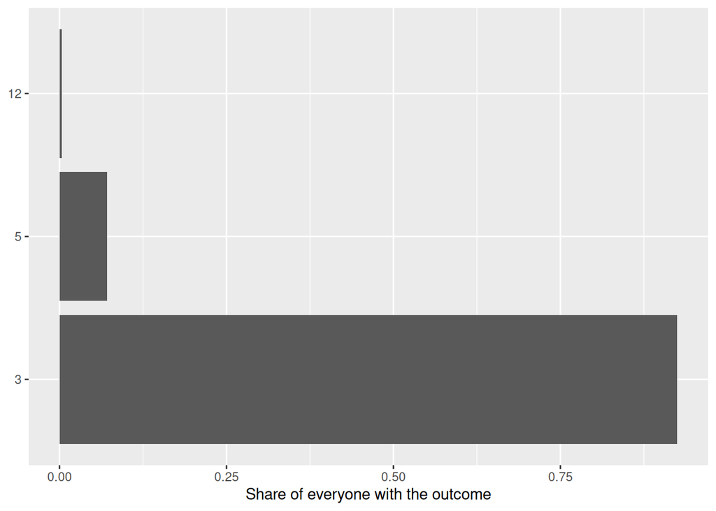

Figure 8: Each group’s share of everyone with the outcome.

```r
b4_shares <- b_data %>%
  filter(has_outcome) %>%
  count(group) %>%
  mutate(share = n / sum(n))

b4 <- ggplot(b4_shares, aes(x = share, y = group)) +
  geom_col() +
  labs(x = "Share of everyone with the outcome", y = NULL)

show_plot(b4)
```

## Checks

Table 2: Every task’s check, at the time this page was rendered.

| task | status |
| --- | --- |
| A0 | PASS |
| A1 | PASS |
| A2 | PASS |
| A3 | PASS |
| A4 | PASS |
| B0 | PASS |
| B1 | PASS |
| B2 | PASS |
| B3 | PASS |
| B4 | PASS |

## References

WRITE: References: Becker, B. & Kohavi, R. (1996). *Adult* [Dataset]. UCI Machine Learning Repository. https://doi.org/10.24432/C5XW20. Accessed through Fairlearn (`fetch_adult`). MMA decisions. MMA Decisions. (n.d.). http://mmadecisions.com/ ESPN Internet Ventures. (n.d.). MMA on ESPN - UFC, PFL and Bellator Fights Coverage. ESPN. https://www.espn.com/mma/